# Differential Expression-like analysis

Nastassia Gobet, Maxime Jan

3 September 2019 -

# GOAL

Perform differential expression-like analysis, expect that to compare mapping on D2 or B6 mm10 primary assembly (refered after as B6). Differential mapping analysis.

# DATA

## gene expression table

The input data are raw counts of gene expression (counted per sample by ht-count, then grouped). Rows are genes and columns are libraries/samples. (One library per sample, no replicate except for parental lines). Samples are lines + condition (SD or NSD).

### Loading

```r
# Import the raw counts table for counts mapped on D2
countsD2 <- read.table("F:/BXD/data/transcriptome/3_counting_htseq/OnGenome/D2/SummaryCountD2.tab", header=TRUE, row.names=1, stringsAsFactors=FALSE)
# Import the raw counts table for counts mapped on B6
countsB6 <- read.table("F:/BXD/data/transcriptome/3_counting_htseq/OnGenome/B6mm10_primaryassembly/SummaryCountB6mm10_primaryassembly.tab", header=TRUE, row.names=1, stringsAsFactors=FALSE)

# change X into C (for cortex) in colnames
colnames(countsD2) <- gsub("X","C", colnames(countsD2))
colnames(countsB6) <- gsub("X","C", colnames(countsB6))

# add C for parental and F1 samples from cortex
colnames(countsD2)[grep("^[BD]", colnames(countsD2))] <- paste("C", colnames(countsD2)[grep("^[BD]", colnames(countsD2))], sep="")
colnames(countsB6)[grep("^[BD]", colnames(countsB6))] <- paste("C", colnames(countsB6)[grep("^[BD]", colnames(countsB6))], sep="")
```

There are 176 libraries and 40177 genes in D2 counts. There are 176 libraries and 54532 genes in B6 counts.

### Dealing with gene names

Convert geneID into gene names, remove duplicate gene names, keep only gene names common to D2 and B6.

```r
# load D2 geneID to gene name convert table
D2geneConvert <- read.table("F:/BXD/references/gene_names_D2.tab", header=FALSE, stringsAsFactors=FALSE, sep=" ")
colnames(D2geneConvert) <- c("GeneID", "GeneName")
# remove replicate gene names
D2geneConvert <- D2geneConvert[-which(duplicated(D2geneConvert$GeneName)),]
rownames(D2geneConvert) <- 1:nrow(D2geneConvert)
### could be improved by adding the counts from different transcripts

B6mm10geneConvert <- read.table("F:/BXD/references/gene_names_B6mm10.tab", header=FALSE, stringsAsFactors=FALSE, sep=" ")
colnames(B6mm10geneConvert) <- c("GeneID", "GeneName")
# remove B6 replicate gene names
B6mm10geneConvert <- B6mm10geneConvert[-which(duplicated(B6mm10geneConvert$GeneName)),]
rownames(B6mm10geneConvert) <- 1:nrow(B6mm10geneConvert)
### could be improved by adding the counts from different transcripts

# try to find B6 matching names
idx <- na.omit(match(rownames(countsB6),B6mm10geneConvert$GeneID))
# take B6 subset
countsB6 <- countsB6[B6mm10geneConvert$GeneID[idx],]

# convert B6 rownames (GeneID) into gene name
rownames(countsB6) <- B6mm10geneConvert$GeneName[idx]

# try to find D2 matching names
idx <- na.omit(match(rownames(countsD2),D2geneConvert$GeneID))
# take D2 subset
countsD2 <- countsD2[D2geneConvert$GeneID[idx],]

# convert D2 rownames (GeneID) into gene name
rownames(countsD2) <- D2geneConvert$GeneName[idx]

# find which genes are common between B6 and D2
commongenes <- intersect(rownames(countsD2), rownames(countsB6))
# get back geneID of common genes
any(is.na(match(commongenes, B6mm10geneConvert$GeneName)))
```

```
## [1] FALSE
```

```r
any(is.na(match(commongenes, D2geneConvert$GeneName)))
```

```
## [1] FALSE
```

```r
commongenesB6id <- B6mm10geneConvert$GeneID[match(commongenes, B6mm10geneConvert$GeneName)]
commongenesD2id <- D2geneConvert$GeneID[match(commongenes, D2geneConvert$GeneName)]
# save common gene names
write.table(commongenes, file="F:/BXD/data/transcriptome/3_counting_htseq/OnGenome/commongenes.txt", col.names=FALSE, row.names=FALSE, quote=FALSE)
# save common genes names B6 id
write.table(commongenesB6id, file="F:/BXD/data/transcriptome/3_counting_htseq/OnGenome/commongenesB6id.txt", col.names=FALSE, row.names=FALSE, quote=FALSE)
# save common genes names D2 id
write.table(commongenesD2id, file="F:/BXD/data/transcriptome/3_counting_htseq/OnGenome/commongenesD2id.txt", col.names=FALSE, row.names=FALSE, quote=FALSE)

# keep only genes in common between B6 and D2 (and ensure that rownames is the same in both dataset)
countsD2 <- countsD2[commongenes,]
countsB6 <- countsB6[commongenes,]
```

There are 29380 genes in D2 counts and 29380 genes in B6 counts.

### Splitting

Splitting between tissue (cortex and liver)

```r
# add mapping reference in column names
colnames(countsD2) <- paste(colnames(countsD2), "D2", sep="_")
colnames(countsB6) <- paste(colnames(countsB6), "B6", sep="_")

# separate tissue instead of mapping reference
countsCortex <- cbind(countsD2[,grep("C", colnames(countsD2))], countsB6[,grep("C", colnames(countsB6))])
countsLiver <- cbind(countsD2[,grep("L", colnames(countsD2))],countsB6[,grep("L", colnames(countsB6))])
```

# Analysis

## Filtering

We want to filter the expression data to take only gene with average expression above 10. This is an arbitrary threshold to remove genes that are of low abundance, more likely to be noisy.

```r
# create a subset of the count table, filtering out rows (genes) with average counts <= 10
##countsCortex10 <- countsCortex[which(apply(countsCortex, MARGIN=1, FUN=mean)>10),]
##countsLiver10 <- countsLiver[which(apply(countsLiver, MARGIN=1, FUN=mean)>10),]
countsCortex <- countsCortex[which(apply(countsCortex, MARGIN=1, FUN=mean)>10),]
countsLiver <- countsLiver[which(apply(countsLiver, MARGIN=1, FUN=mean)>10),]

# create a function that plots the histogram + density curve
plotHistDensity <- function(dataset){
  hist(dataset, freq=FALSE)
  lines(density(dataset), lwd=2)
}
##plotHistDensity(rnorm(10000))
##par(mfrow=c(1,2))
##plotHistDensity(log10(unlist(apply(countsCortex, MARGIN=1, FUN=mean))))
##plotHistDensity(log10(unlist(apply(countsCortex10, MARGIN=1, FUN=mean))))
##plotHistDensity(log10(unlist(apply(countsLiver, MARGIN=1, FUN=mean))))
##plotHistDensity(log10(unlist(apply(countsLiver10, MARGIN=1, FUN=mean))))
```

The filtered datasets have 13885 genes in cortex and 11150 genes in liver.

## Standarization

The normalization is performed using the Weighted trimmed mean of M-values (TMM) method of the edgeR package. This step standarizes the counts gene expression to take into account the variation in library size (=number of counts per library), the variation in length of the transcripts, and in RNA population variation. (Robinson, Genome Biology, 2010).

```r
# formatting for edgeR (creates a DGEList object from the dataframe)
dC <- DGEList(counts=countsCortex)
dL <- DGEList(counts=countsLiver)

# calculate the normalization factors for each sample TMM method (effective library size)
dC <- calcNormFactors(dC, method="TMM")
dL <- calcNormFactors(dL, method="TMM")

# calculate CPM and normalize the counts
normalizedCPMcountsCortex <- data.frame(cpm(dC, normalized.lib.sizes=TRUE))
normalizedCPMcountsLiver <- data.frame(cpm(dL, normalized.lib.sizes=TRUE))

# Export normalized CPM
write.table(normalizedCPMcountsCortex, file="F:/BXD/data/transcriptome/4_normalization/D2B6_edgeRTMMnormalized_CPM_Cortex.tab", row.names=TRUE, sep="\t", quote=FALSE)
write.table(normalizedCPMcountsLiver, file="F:/BXD/data/transcriptome/4_normalization/D2B6_edgeRTMMnormalized_CPM_Liver.tab", row.names=TRUE, sep="\t", quote=FALSE)
```

## Differential gene mapping

Find which genes appear up- or down-regulated if mapping on reference rather than the other.

This is done here using voom from limma package.

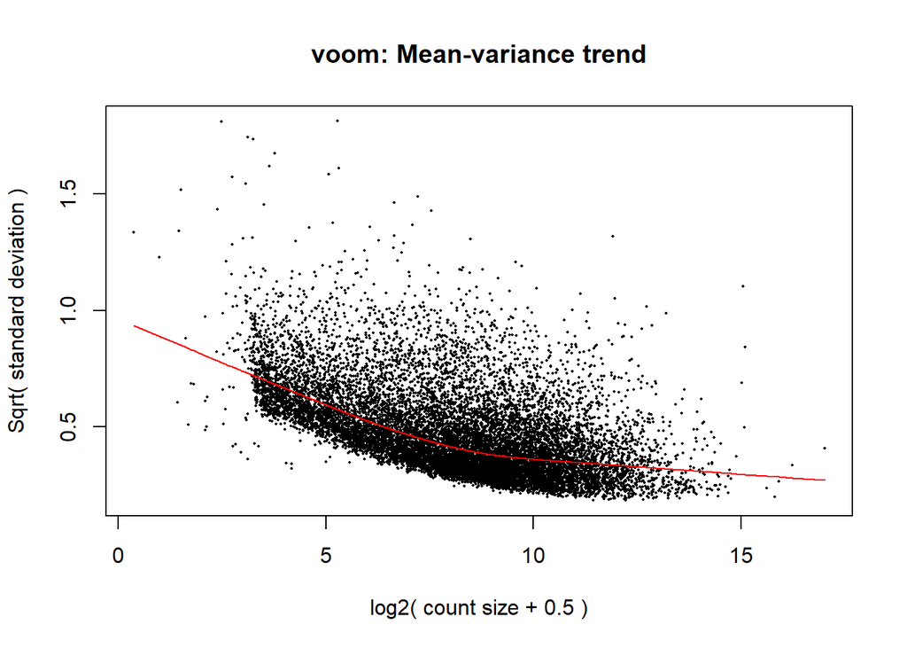

```r
# prepare the design
variables <- matrix(unlist(strsplit(colnames(normalizedCPMcountsCortex), "_")), ncol=2, byrow=TRUE)
colnames(variables) <- c("samplename","mappingref")
strains <- factor(gsub("[Cnsd]","",variables[,"samplename"]))
design <- model.matrix(~strains+factor(variables[,"mappingref"]))

# by default the normalization method is quantile (voom calls normalizeBetweenArrays)
# plot the mean-variance trend
##res <- voom(countsCortex, design, plot=TRUE, lib.size=colSums(countsCortex)*dC$samples$norm.factors)
resC <- voom(dC, design, plot=TRUE)
```

```r
resCortexNorm <- resC$E

# fitting
# fit the coefficient of the linear model
fitC <- lmFit(resC, design)
# calculates the t-statistics
fitC2 <- eBayes(fitC)

# write all results
resultTable <- topTable(fitC2, coef=ncol(fitC$coefficients), adjust="fdr", sort.by="B", number=1000000)
# sort by adjusted p-value
resultTable <- resultTable[order(resultTable$adj.P.Val),]

# store information about DE analysis
write.table(resultTable, file="F:/BXD/data/transcriptome/5_DifferentialMapping/DifferentialMapping_Limma_Cortex.txt", row.names=TRUE, sep="\t", quote=FALSE)
```

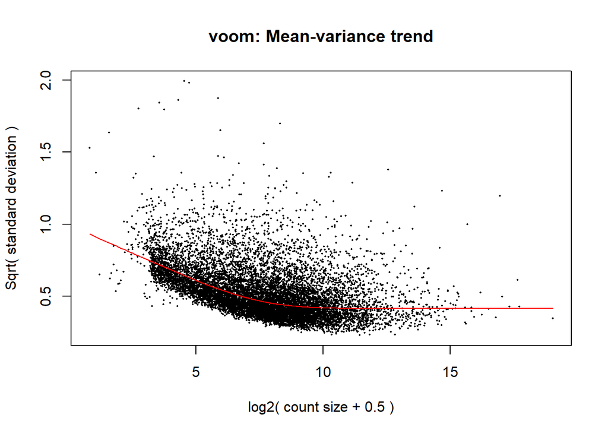

```r
# prepare the design
variables <- matrix(unlist(strsplit(colnames(normalizedCPMcountsLiver), "_")), ncol=2, byrow=TRUE)
colnames(variables) <- c("samplename","mappingref")
strains <- factor(gsub("[Cnsd]","",variables[,"samplename"]))
design <- model.matrix(~strains+factor(variables[,"mappingref"]))

# by default the normalization method is quantile (voom calls normalizeBetweenArrays)
# plot the mean-variance trend
##res <- voom(countsLiver, design, plot=TRUE, lib.size=colSums(countsLiver)*dL$samples$norm.factors)
resL <- voom(dL, design, plot=TRUE)
```

```r
resLiverNorm <- resL$E

# fitting
# fit the coefficient of the linear model
fitL <- lmFit(resL, design)
# calculates the t-statistics
fitL2 <- eBayes(fitL)

# write all results
resultTable <- topTable(fitL2, coef=ncol(fitL$coefficients), adjust="fdr", sort.by="B", number=1000000)
# sort by adjusted p-value
resultTable <- resultTable[order(resultTable$adj.P.Val),]

# store information about DE analysis
write.table(resultTable, file="F:/BXD/data/transcriptome/5_DifferentialMapping/DifferentialMapping_Limma_Liver.txt", row.names=TRUE, sep="\t", quote=FALSE)
```

# Plotting results

Volcano plots

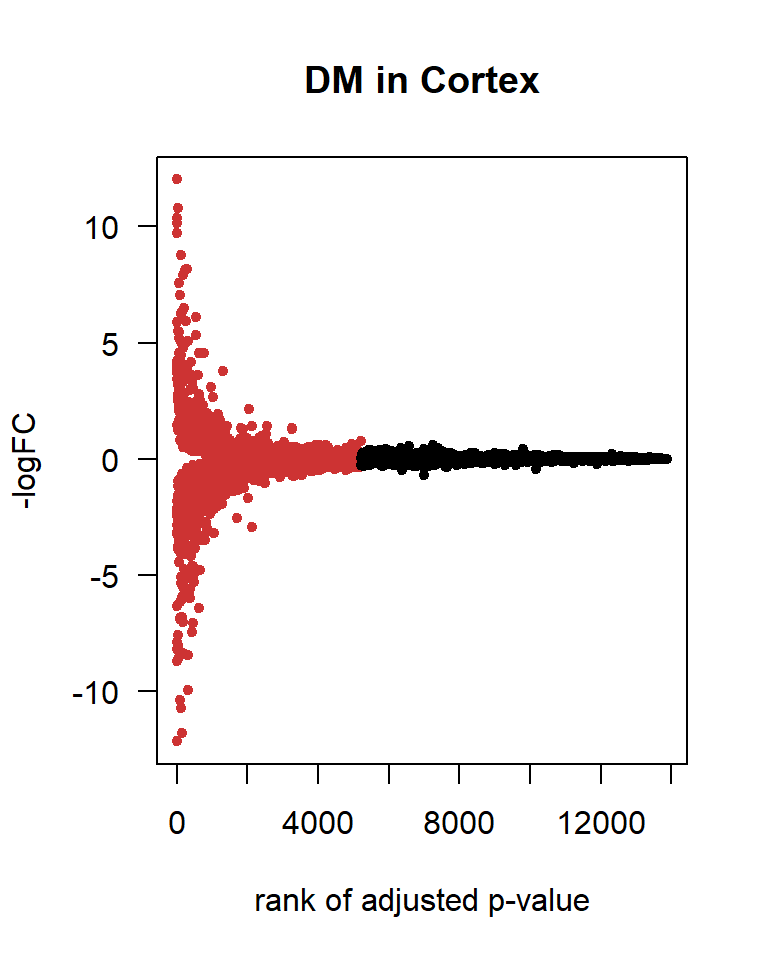

```r
# load table with results of differential expression
DMdata_Cortex <- read.table('F:/BXD/data/transcriptome/5_DifferentialMapping/DifferentialMapping_Limma_Cortex.txt', sep="\t")
DMdata_Liver <- read.table('F:/BXD/data/transcriptome/5_DifferentialMapping/DifferentialMapping_Limma_Liver.txt', sep="\t")

# volcano plot all transcripts in black and significant in red
# set the colors
palette(c("black", "brown3"))

# plot for Cortex
plot(1:nrow(DMdata_Cortex), DMdata_Cortex$logFC, las=1, pch=20, col=as.factor(DMdata_Cortex$adj.P.Val<=0.05),
       main="DM in Cortex", xlab="rank of adjusted p-value", ylab="-logFC")
```

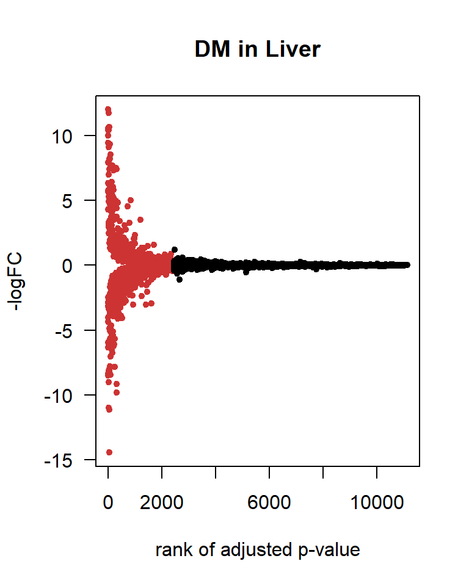

```r
# plot for Liver
plot(1:nrow(DMdata_Liver), DMdata_Liver$logFC, las=1, pch=20, col=as.factor(DMdata_Liver$adj.P.Val<=0.05),
       main="DM in Liver", xlab="rank of adjusted p-value", ylab="-logFC")
```

The -logFC represents ratio of D2 over B6 (positive values map better on D2, negative values map better on B6).

38% of genes are significantly (below or equal to 0.05) differentially mapped in cortex, and 22% in liver.

```r
# get top 5 up- and top 5 down-measured genes
DMdata_Cortex <- DMdata_Cortex[order(DMdata_Cortex$logFC),]
head(DMdata_Cortex,5)
```

|  | logFC | AveExpr | t | P.Value | adj.P.Val | B |
| --- | --- | --- | --- | --- | --- | --- |
| Nova2 | -12.164698 | 1.3648420 | -268.06321 | 5.882332e-184 | 2.041905e-180 | 394.8283 |
| mt-Nd6 | -11.818839 | 1.1919892 | -91.89010 | 2.156985e-122 | 1.970378e-120 | 268.6990 |
| Ltbp4 | -10.732239 | 0.6485381 | -96.64212 | 2.874989e-125 | 2.956979e-123 | 275.0933 |
| Gm9843 | -10.376615 | 1.4178869 | -102.76908 | 8.870558e-129 | 1.129979e-126 | 282.9201 |
| Fndc10 | -9.979704 | 0.2719953 | -63.31718 | 2.503437e-101 | 1.056542e-99 | 221.1740 |

```r
print(head(DMdata_Cortex[,c("logFC","adj.P.Val")],5))
```

```
##             logFC     adj.P.Val
## Nova2  -12.164698 2.041905e-180
## mt-Nd6 -11.818839 1.970378e-120
## Ltbp4  -10.732239 2.956979e-123
## Gm9843 -10.376615 1.129979e-126
## Fndc10  -9.979704  1.056542e-99
```

```r
tail(DMdata_Cortex,5)
```

|  | logFC | AveExpr | t | P.Value | adj.P.Val | B |
| --- | --- | --- | --- | --- | --- | --- |
| Atp5o | 10.13516 | 0.3194963 | 268.7254 | 4.236564e-184 | 1.960823e-180 | 394.9515 |
| Raver1 | 10.36631 | 0.4350508 | 308.3249 | 4.833325e-192 | 6.711071e-188 | 408.2602 |
| Hgs | 10.36801 | 0.4358853 | 241.1942 | 7.406921e-178 | 1.469216e-174 | 383.8576 |
| Gm5160 | 10.79142 | 0.8998691 | 142.7247 | 1.298103e-147 | 5.149759e-145 | 323.7151 |
| Gm43796 | 12.02661 | 1.2653927 | 243.6838 | 1.890975e-178 | 5.251237e-175 | 385.0171 |

```r
print(tail(DMdata_Cortex[,c("logFC","adj.P.Val")],5))
```

```
##            logFC     adj.P.Val
## Atp5o   10.13516 1.960823e-180
## Raver1  10.36631 6.711071e-188
## Hgs     10.36801 1.469216e-174
## Gm5160  10.79142 5.149759e-145
## Gm43796 12.02661 5.251237e-175
```

```r
DMdata_Liver <- DMdata_Liver[order(DMdata_Liver$logFC),]
head(DMdata_Liver,5)
```

|  | logFC | AveExpr | t | P.Value | adj.P.Val | B |
| --- | --- | --- | --- | --- | --- | --- |
| Gm15564 | -14.429538 | 3.1130090 | -102.90999 | 2.709259e-129 | 6.041648e-127 | 284.4552 |
| mt-Nd6 | -11.130594 | 1.1404739 | -105.63340 | 8.567214e-131 | 2.122765e-128 | 287.7874 |
| Gm9843 | -11.010413 | 2.1419383 | -108.08757 | 4.103230e-132 | 1.089310e-129 | 290.7256 |
| mt-Ti | -9.817255 | 0.4854728 | -42.19051 | 3.431154e-79 | 1.159314e-77 | 170.5209 |
| H2-T22 | -9.144818 | 1.8588382 | -43.24932 | 1.557298e-80 | 5.460337e-79 | 173.6094 |

```r
print(head(DMdata_Liver[,c("logFC","adj.P.Val")],5))
```

```
##              logFC     adj.P.Val
## Gm15564 -14.429538 6.041648e-127
## mt-Nd6  -11.130594 2.122765e-128
## Gm9843  -11.010413 1.089310e-129
## mt-Ti    -9.817255  1.159314e-77
## H2-T22   -9.144818  5.460337e-79
```

```r
tail(DMdata_Liver,5)
```

|  | logFC | AveExpr | t | P.Value | adj.P.Val | B |
| --- | --- | --- | --- | --- | --- | --- |
| Rpl36-ps3 | 10.42071 | 1.1743836 | 114.21794 | 2.757120e-135 | 9.041731e-133 | 297.7310 |
| Atp5o | 10.56888 | 0.8354603 | 186.40843 | 1.413265e-163 | 3.151581e-160 | 358.1144 |
| Gm26445 | 10.65421 | 0.9140324 | 93.98037 | 4.341414e-124 | 7.356514e-122 | 272.8232 |
| Gm27331 | 11.72673 | 1.4143245 | 120.12765 | 3.436727e-138 | 1.473827e-135 | 304.1265 |
| Gm44805 | 11.99471 | 1.5482340 | 196.37998 | 1.355069e-166 | 5.036339e-163 | 364.2570 |

```r
print(tail(DMdata_Liver[,c("logFC","adj.P.Val")],5))
```

```
##              logFC     adj.P.Val
## Rpl36-ps3 10.42071 9.041731e-133
## Atp5o     10.56888 3.151581e-160
## Gm26445   10.65421 7.356514e-122
## Gm27331   11.72673 1.473827e-135
## Gm44805   11.99471 5.036339e-163
```

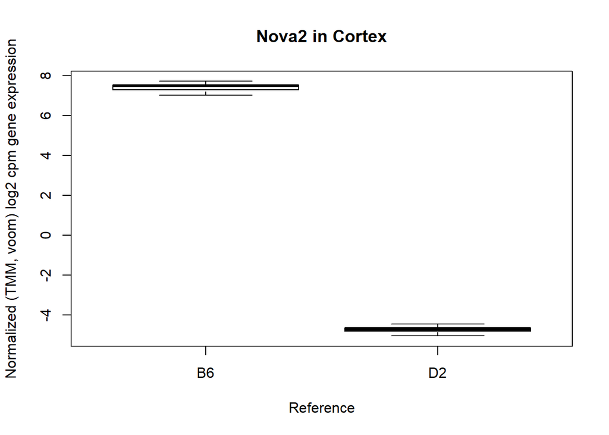

```
## $stats
##          [,1]      [,2]
## [1,] 7.043672 -5.039554
## [2,] 7.307697 -4.801528
## [3,] 7.502765 -4.710219
## [4,] 7.560684 -4.624235
## [5,] 7.728568 -4.445441
##
## $n
## [1] 88 88
##
## $conf
##          [,1]      [,2]
## [1,] 7.460155 -4.740080
## [2,] 7.545376 -4.680358
##
## $out
## numeric(0)
##
## $group
## numeric(0)
##
## $names
## [1] "B6" "D2"
```

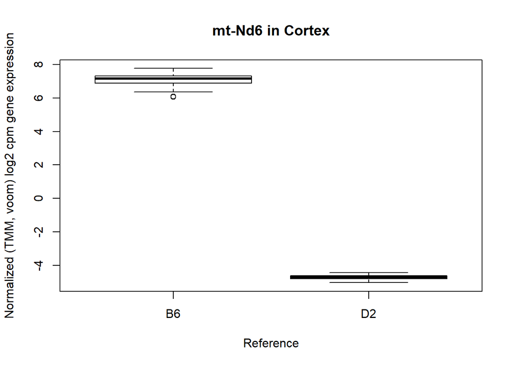

```
## $stats
##          [,1]      [,2]
## [1,] 6.367475 -5.039554
## [2,] 6.889330 -4.801528
## [3,] 7.153041 -4.710219
## [4,] 7.330658 -4.624235
## [5,] 7.765970 -4.445441
##
## $n
## [1] 88 88
##
## $conf
##          [,1]      [,2]
## [1,] 7.078709 -4.740080
## [2,] 7.227373 -4.680358
##
## $out
## [1] 6.063334 6.078157
##
## $group
## [1] 1 1
##
## $names
## [1] "B6" "D2"
```

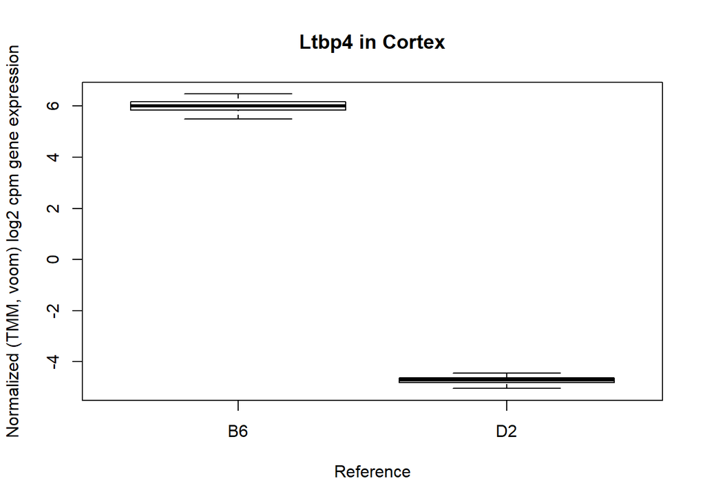

```
## $stats
##          [,1]      [,2]
## [1,] 5.503973 -5.039554
## [2,] 5.847776 -4.801528
## [3,] 6.013128 -4.710219
## [4,] 6.181556 -4.624235
## [5,] 6.472881 -4.445441
##
## $n
## [1] 88 88
##
## $conf
##          [,1]      [,2]
## [1,] 5.956910 -4.740080
## [2,] 6.069346 -4.680358
##
## $out
## numeric(0)
##
## $group
## numeric(0)
##
## $names
## [1] "B6" "D2"
```

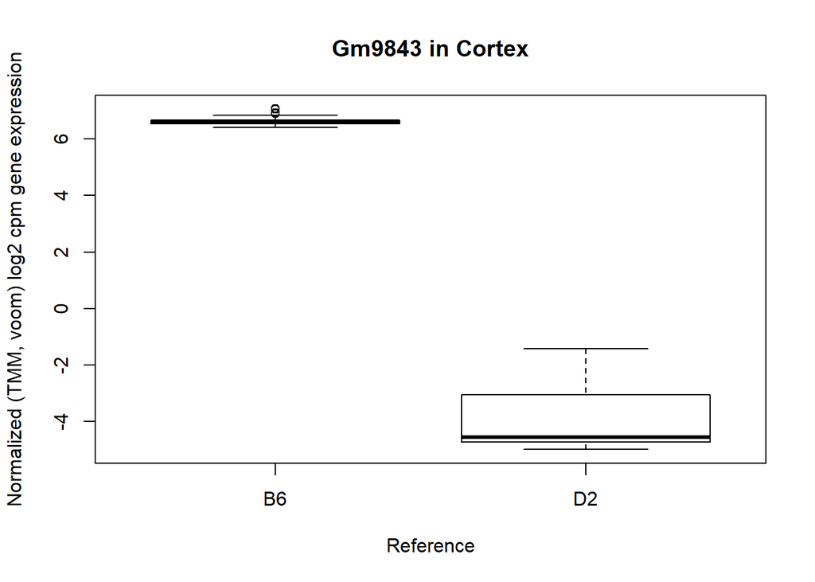

```
## $stats
##          [,1]      [,2]
## [1,] 6.409097 -4.983664
## [2,] 6.542129 -4.716249
## [3,] 6.601531 -4.551227
## [4,] 6.671155 -3.039602
## [5,] 6.835269 -1.416907
##
## $n
## [1] 88 88
##
## $conf
##          [,1]      [,2]
## [1,] 6.579799 -4.833622
## [2,] 6.623263 -4.268832
##
## $out
## [1] 7.047892 6.896878 7.069806 6.929555
##
## $group
## [1] 1 1 1 1
##
## $names
## [1] "B6" "D2"
```

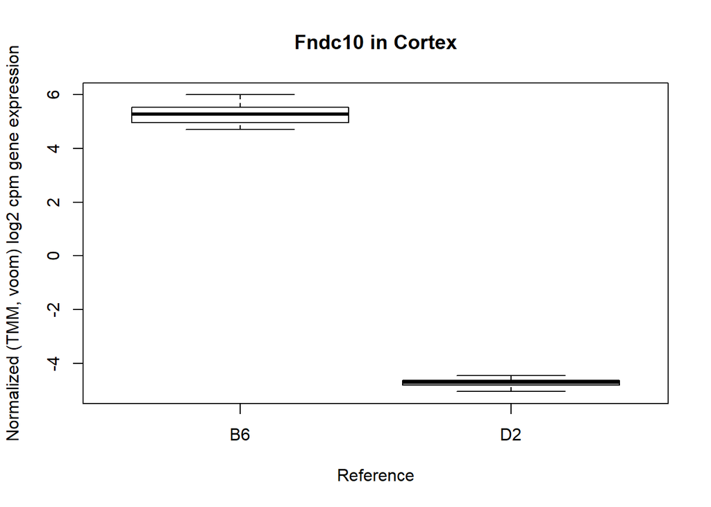

```
## $stats
##          [,1]      [,2]
## [1,] 4.700071 -5.039554
## [2,] 4.964314 -4.801528
## [3,] 5.263207 -4.710219
## [4,] 5.518980 -4.624235
## [5,] 5.987569 -4.445441
##
## $n
## [1] 88 88
##
## $conf
##          [,1]      [,2]
## [1,] 5.169785 -4.740080
## [2,] 5.356628 -4.680358
##
## $out
## numeric(0)
##
## $group
## numeric(0)
##
## $names
## [1] "B6" "D2"
```

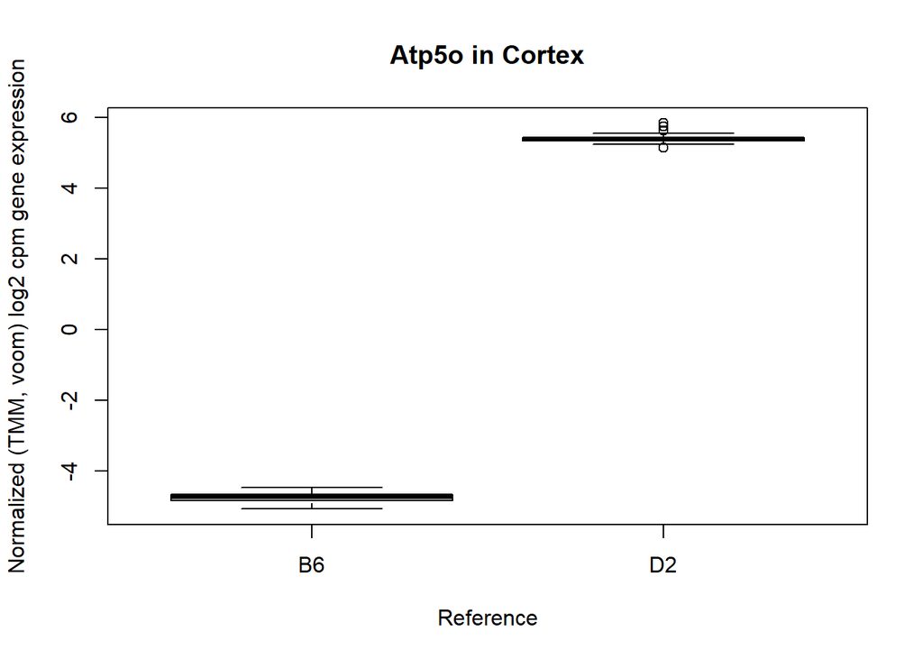

```
## $stats
##           [,1]     [,2]
## [1,] -5.065441 5.227313
## [2,] -4.834957 5.333712
## [3,] -4.733287 5.385098
## [4,] -4.656502 5.433982
## [5,] -4.459681 5.546457
##
## $n
## [1] 88 88
##
## $conf
##           [,1]     [,2]
## [1,] -4.763344 5.368210
## [2,] -4.703230 5.401986
##
## $out
## [1] 5.829300 5.621332 5.747144 5.140811
##
## $group
## [1] 2 2 2 2
##
## $names
## [1] "B6" "D2"
```

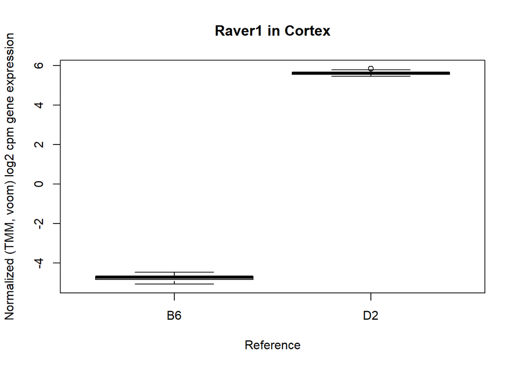

```
## $stats
##           [,1]     [,2]
## [1,] -5.065441 5.461985
## [2,] -4.834957 5.558888
## [3,] -4.733287 5.615340
## [4,] -4.656502 5.669035
## [5,] -4.459681 5.788656
##
## $n
## [1] 88 88
##
## $conf
##           [,1]     [,2]
## [1,] -4.763344 5.596788
## [2,] -4.703230 5.633892
##
## $out
## [1] 5.840854
##
## $group
## [1] 2
##
## $names
## [1] "B6" "D2"
```

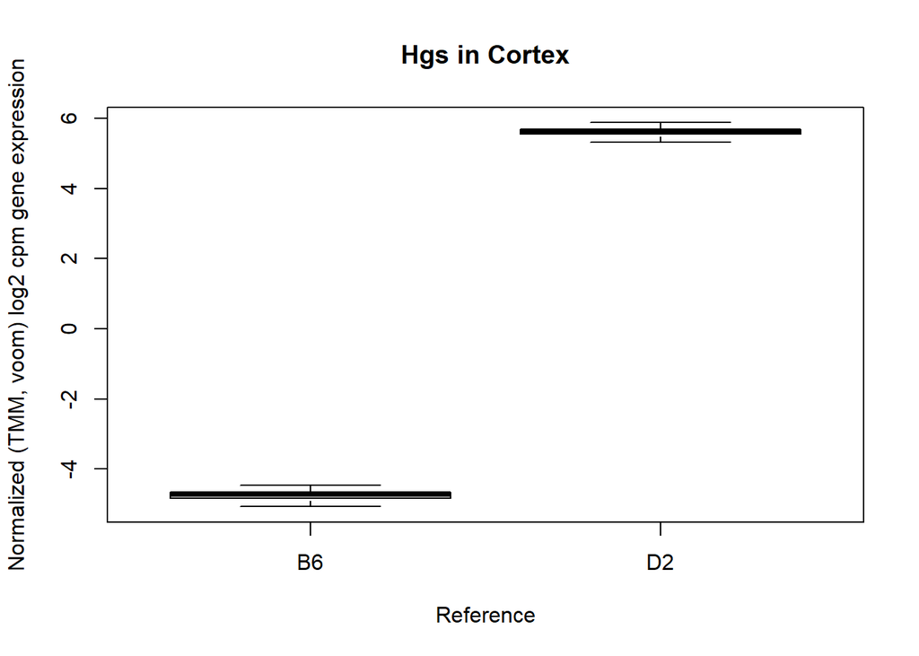

```
## $stats
##           [,1]     [,2]
## [1,] -5.065441 5.323050
## [2,] -4.834957 5.539773
## [3,] -4.733287 5.621279
## [4,] -4.656502 5.690882
## [5,] -4.459681 5.871849
##
## $n
## [1] 88 88
##
## $conf
##           [,1]     [,2]
## [1,] -4.763344 5.595828
## [2,] -4.703230 5.646730
##
## $out
## numeric(0)
##
## $group
## numeric(0)
##
## $names
## [1] "B6" "D2"
```

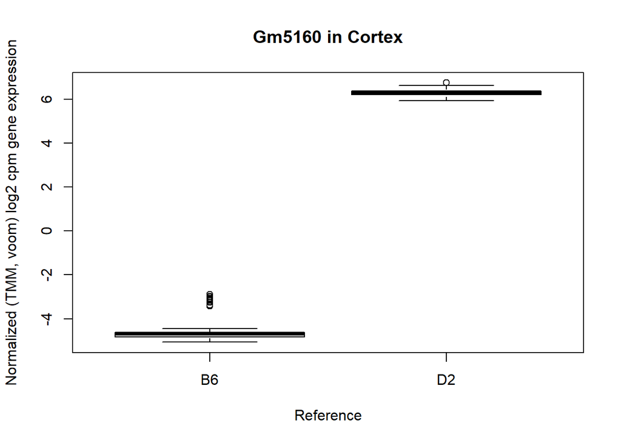

```
## $stats
##           [,1]     [,2]
## [1,] -5.065441 5.931815
## [2,] -4.827391 6.196030
## [3,] -4.704323 6.295569
## [4,] -4.627655 6.383832
## [5,] -4.459681 6.622473
##
## $n
## [1] 88 88
##
## $conf
##           [,1]     [,2]
## [1,] -4.737964 6.263938
## [2,] -4.670682 6.327200
##
## $out
##  [1] -3.253223 -3.008793 -3.232791 -2.995551 -3.095792 -3.373992 -3.228916
##  [8] -3.070858 -3.169261 -3.416979 -3.011493 -2.971593 -2.893229 -3.126597
## [15]  6.744341
##
## $group
##  [1] 1 1 1 1 1 1 1 1 1 1 1 1 1 1 2
##
## $names
## [1] "B6" "D2"
```

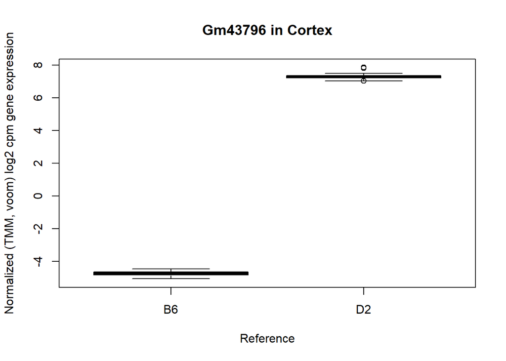

```
## $stats
##           [,1]     [,2]
## [1,] -5.065441 7.025115
## [2,] -4.834957 7.213812
## [3,] -4.733287 7.271243
## [4,] -4.656502 7.341773
## [5,] -4.459681 7.473380
##
## $n
## [1] 88 88
##
## $conf
##           [,1]     [,2]
## [1,] -4.763344 7.249691
## [2,] -4.703230 7.292795
##
## $out
## [1] 7.795961 7.016485 7.842211
##
## $group
## [1] 2 2 2
##
## $names
## [1] "B6" "D2"
```

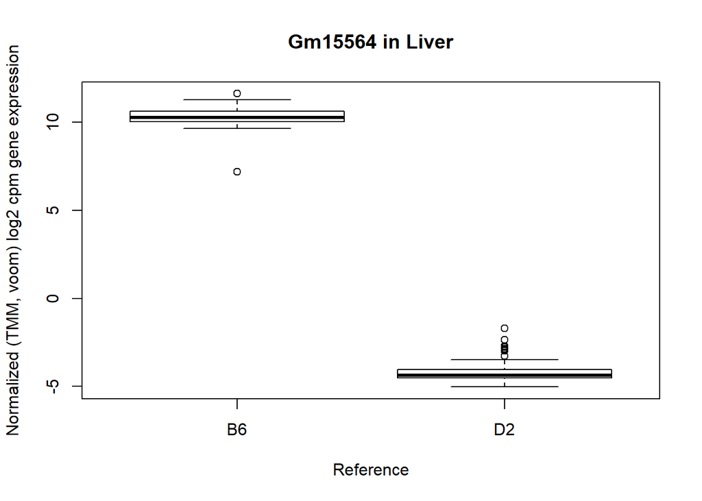

```
## $stats
##           [,1]      [,2]
## [1,]  9.653593 -5.021304
## [2,] 10.048506 -4.524748
## [3,] 10.285110 -4.349790
## [4,] 10.624612 -4.034513
## [5,] 11.272912 -3.477235
##
## $n
## [1] 88 88
##
## $conf
##          [,1]     [,2]
## [1,] 10.18808 -4.43236
## [2,] 10.38214 -4.26722
##
## $out
##  [1] 11.629664  7.194823 -2.769085 -2.694117 -3.279343 -1.684976 -2.723311
##  [8] -2.344943 -2.689075 -2.725403 -2.777130 -2.939493 -2.953512 -2.843281
## [15] -2.971091 -2.855589 -2.892962
##
## $group
##  [1] 1 1 2 2 2 2 2 2 2 2 2 2 2 2 2 2 2
##
## $names
## [1] "B6" "D2"
```

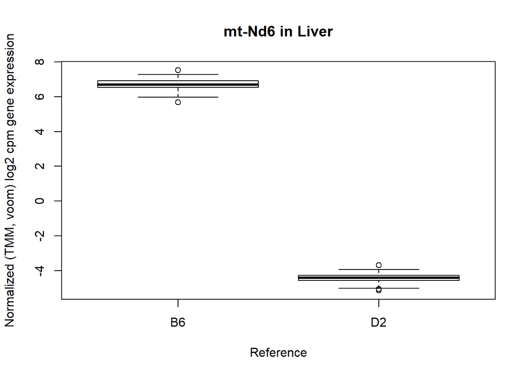

```
## $stats
##          [,1]      [,2]
## [1,] 5.982220 -5.021304
## [2,] 6.538274 -4.575100
## [3,] 6.704167 -4.414535
## [4,] 6.918927 -4.274824
## [5,] 7.295258 -3.944410
##
## $n
## [1] 88 88
##
## $conf
##          [,1]     [,2]
## [1,] 6.640055 -4.46511
## [2,] 6.768280 -4.36396
##
## $out
## [1]  7.525928  5.695123 -5.062197 -5.140885 -3.682604
##
## $group
## [1] 1 1 2 2 2
##
## $names
## [1] "B6" "D2"
```

[8 more figures not shown]

```
## $stats
##           [,1]     [,2]
## [1,] -5.030219 6.985496
## [2,] -4.599617 7.367367
## [3,] -4.443848 7.519018
## [4,] -4.296034 7.683739
## [5,] -3.944605 8.095076
##
## $n
## [1] 88 88
##
## $conf
##           [,1]     [,2]
## [1,] -4.494980 7.465732
## [2,] -4.392716 7.572304
##
## $out
## [1] -5.111773 -5.181703 -3.702662  8.246057  8.685811
##
## $group
## [1] 1 1 1 2 2
##
## $names
## [1] "B6" "D2"
```

```r
for (mytissue in c("Cortex","Liver")){
  completelist <- rownames(get(paste("DMdata_", mytissue, sep="")))
  for (mygene in c(head(completelist, 5), tail(completelist, 5))){
    print(boxplot(as.numeric(get(paste("res", mytissue, "Norm", sep=""))[mygene,]) ~ factor(variables[, "mappingref"]), main=paste(mygene, "in", mytissue), xlab="Reference", ylab="Normalized (TMM, voom) log2 cpm gene expression"))
  }
}
```

```r
### try to understand why logFC for B6 of more than 10 seems less when I check the (normalized) values
##apply(resC$E,1,FUN=(function(x) mean(x[89:176]-mean(x[1:88]))))

# For Raver1 Cortex, overlap with Gm38431 in B6 but not present in D2, so coverage look similar but counts are 0 for B6
# Maybe look at the source of annotation for B6 and filter out some if not trustfull. Gm38431 comes from havana
```